# Tomorrow's Rain Prediction

> **Note:** This master thesis' main effort relies on the data pipeline itself (Ingestion, Transformation, Orchestration). Data products such as this one are included as proof that, indeed, the pipeline's data is usable and can be relied upon, and have been included for the sake of completeness.

In the following notebook we evaluate two different classifier models (Random Forest and Gradient Boosting) for predicting wether the following day it's going to rain or not.

The data is taken live from the ADLS account hosting the `rain_prediction.parquet` dataset. This dataset is updated daily via an automated data pipeline that ingests data from the OpenWeatherMaps API. The ingested data is later transformed until it lands, mostly clean, in the before mentioned dataset.

We start by importing the required libraries and creating a helper class for interacting with polars dataframes and plotly figures.

```python
# Standard lib
import sys
from pathlib import Path

# External libs
import polars as pl

import plotly.graph_objects as go
import plotly.io as pio
import plotly.express as px
from plotly.subplots import make_subplots

from dotenv import load_dotenv

from sklearn.model_selection import train_test_split
from sklearn.ensemble import RandomForestClassifier, GradientBoostingClassifier
from sklearn.metrics import confusion_matrix, ConfusionMatrixDisplay

from imblearn.over_sampling import ADASYN

from matplotlib import pyplot as plt

# Custom lib
sys.path.insert(0, "../openweather-functions/")

from src.destinations.adls import ADLS

# Requires a ./.env file with the following variables in order to authenticate to ADLS
# AZURE_CLIENT_SECRET=""
# AZURE_CLIENT_ID=""
# AZURE_TENANT_ID=""
# AZURE_ACCOUNT_NAME=""
# AZURE_CONTAINER_NAME=""
_ = load_dotenv()

# Required for exporting the plotly figures into HTML
pio.renderers.default = "notebook"


class Label(str):
    """Helper class for pretty printing labels in with plotly"""

    def __init__(self, label):
        super(Label, self).__init__()
        self.name = label
        self.pretty = label.replace("_", " ").capitalize()
```

## Dataset exploration and preparation

Download the dataset and create a polars dataframe.

```python
file_name = "rain_prediction.parquet"
adls = ADLS(directory="ml")

try:
    adls.download_file(file_name, file_name)
    df = pl.read_parquet(file_name)
finally:
    Path(file_name).unlink(missing_ok=True)

df.head()
```

```
ADLS: Using default envrionment credentials
ADLS: Initializing DataLakeServiceClient
```

shape: (5, 15)

| recorded_day date | location str | clouds f64 | temperature_feels_like f64 | avg_temperature f64 | max_temperature f32 | min_temperature f32 | humidity f64 | pressure f64 | degrees f64 | wind_gusts f64 | wind_speed f64 | rain f64 | max_rain f32 | rain_prediction str |
| --- | --- | --- | --- | --- | --- | --- | --- | --- | --- | --- | --- | --- | --- | --- |
| 2024-12-31 | "merida" | 0.0 | 4.140015 | 5.950012 | 5.950012 | 5.950012 | 73.0 | 1030.0 | 55.0 | 2.37 | 2.36 | null | null | "dry" |
| 2025-01-01 | "merida" | 0.375 | 4.890007 | 6.813754 | 13.660004 | -0.339996 | 70.541667 | 1028.875 | 69.0 | 2.96625 | 2.575417 | null | null | "dry" |
| 2025-01-02 | "merida" | 15.583333 | 5.534175 | 6.854588 | 14.660004 | -0.339996 | 69.208333 | 1028.75 | 87.083333 | 1.47875 | 1.4675 | null | null | "dry" |
| 2025-01-03 | "merida" | 80.625 | 6.342503 | 6.78292 | 12.660004 | -1.339996 | 73.541667 | 1027.583333 | 138.375 | 1.44125 | 1.260417 | null | null | "dry" |
| 2025-01-04 | "merida" | 90.583333 | 8.14084 | 9.041672 | 15.660004 | 1.660004 | 77.291667 | 1023.75 | 148.541667 | 2.69625 | 1.882917 | null | null | "light" |

The dataset consists of 15 columns. We are going to use 10 as predictors and 1 (`rain_prediction`) to create a column to be predicted. We are going to ignore the `recorded_day` and `location` columns, since predictions are going to have the information of the current date to predict the next one.

```python
df = df.fill_null(0.0)
min_date = df["recorded_day"].min()
max_date = df["recorded_day"].max()
unique_locations = len(
    df.select(pl.col("location").str.replace_all("_", " ").str.to_uppercase()).unique()
)

print(
    f"Dataset used includes data from {min_date.isoformat()} to {max_date.isoformat()} "
    f"from {unique_locations} distinct locations for a total of {len(df)} entries."
)
```

```
Dataset used includes data from 2024-12-31 to 2025-12-22 from 17 distinct locations for a total of 6172 entries.
```

Plot the distributions of predictive variables plus the rain variables for visual inspection. Note that the rain variables are not going to be used as predictors, and that the predicted variable is going to be created from the `rain_prediction` column instead.

```python
x_labels = [
    Label(x)
    for x in [
        "clouds",
        "temperature_feels_like",
        "avg_temperature",
        "max_temperature",
        "min_temperature",
        "humidity",
        "pressure",
        "degrees",
        "wind_gusts",
        "wind_speed",
    ]
]
plot_labels = x_labels + [Label("rain"), Label("max_rain")]

ROWS = 3
COLS = 4
fig = make_subplots(
    rows=ROWS, cols=COLS, subplot_titles=[label.pretty for label in plot_labels]
)

for idx, label in enumerate(plot_labels):
    fig.add_trace(
        go.Histogram(x=df[label], nbinsx=100),
        row=int(idx / COLS) + 1,
        col=(idx % COLS) + 1,
    )

fig.update_layout(showlegend=False, height=500, width=1000)

fig.show()
```

[interactive chart not shown]

Standardize predictor variables to generate the independent variable set.

```python
X = df.select(
    (pl.col(label) - pl.col(label).mean()) / pl.col(label).std() for label in x_labels
)

X.head()
```

shape: (5, 10)

| clouds f64 | temperature_feels_like f64 | avg_temperature f64 | max_temperature f32 | min_temperature f32 | humidity f64 | pressure f64 | degrees f64 | wind_gusts f64 | wind_speed f64 |
| --- | --- | --- | --- | --- | --- | --- | --- | --- | --- |
| -1.263324 | -1.634785 | -1.584682 | -1.964509 | -0.955828 | 0.208645 | 2.243073 | -1.68934 | -0.525215 | -0.50547 |
| -1.250866 | -1.53296 | -1.457616 | -1.010304 | -1.956304 | 0.055395 | 2.046642 | -1.501414 | -0.365769 | -0.387033 |
| -0.745618 | -1.445502 | -1.451609 | -0.886542 | -1.956304 | -0.027724 | 2.024817 | -1.258676 | -0.763549 | -0.996171 |
| 1.415182 | -1.335757 | -1.462152 | -1.134066 | -2.115362 | 0.242412 | 1.821111 | -0.570172 | -0.773577 | -1.110027 |
| 1.746015 | -1.091599 | -1.129865 | -0.762779 | -1.638188 | 0.476184 | 1.151791 | -0.433702 | -0.437971 | -0.767773 |

Generate the variable to predict. In this case the `rain_prediction` column, which can be `dry`, `light`, `moderate` and `intense` is aggregated into either `dry` or `rain`. This variable indicates wether the following day rained or not and it is what we are going to train our models to predict. Furthermore, create another column that will have `0` or `1` values to indicate the same thing.

```python
df = df.with_columns(
    pl.when(pl.col("rain_prediction").is_in(("light", "moderate", "intense")))
    .then(pl.lit("rain"))
    .otherwise(pl.lit("dry"))
    .alias("simple_rain_prediction"),

).with_columns(
    pl.when(pl.col("simple_rain_prediction") == pl.lit("rain"))
    .then(1)
    .otherwise(0)
    .alias("b_simple_rain_prediction")
)
y = df.select("b_simple_rain_prediction")

df.select("simple_rain_prediction", "b_simple_rain_prediction").head()
```

shape: (5, 2)

| simple_rain_prediction str | b_simple_rain_prediction i32 |
| --- | --- |
| "dry" | 0 |
| "dry" | 0 |
| "dry" | 0 |
| "dry" | 0 |
| "rain" | 1 |

Evaluate the balancedness of the dataset. Currently, the data is obtained from different locations in Spain, therefore, it is expected to be imbalanced towards the dry days.

```python
label_count = (
    df.select(pl.col("simple_rain_prediction"))
    .group_by(pl.col("simple_rain_prediction"))
    .agg(pl.col("simple_rain_prediction").count().alias("count"))
)

fig = px.bar(
    label_count,
    x="simple_rain_prediction",
    y="count",
    title="Label Distribution in Dataset Before Resampling",
    labels={"simple_rain_prediction": "Simple Rain Prediction", "count": "Count"},
    width=500,
    height=500
)

fig.show()
```

[interactive chart not shown]

Separeate the dataset into train and test datasets (80/20).

Furthermore, use `ADASYN` to synthetically balance the training dataset.

```python
X_train, X_test, y_train, y_test = train_test_split(
    X, y, test_size=0.2, random_state=10
)

X_train_resampled, y_train_resampled = ADASYN().fit_resample(X_train.to_numpy(), y_train.to_numpy())

print(f"Total: {len(X)}")
print(f"Training: {len(y_train)}")
print(f"Resampled: {len(y_train_resampled)}")
print(f"Test: {len(y_test)}")
```

```
Total: 6172
Training: 4937
Resampled: 7571
Test: 1235
```

Plot again the count of `dry` and `rain` cases for the resampled training dataset.

```python
label_count_resampled = pl.DataFrame({
    "simple_rain_prediction": ["dry", "rain"],
    "count": [y_train_resampled.size - y_train_resampled.sum(), y_train_resampled.sum()],
})

fig = px.bar(
    label_count_resampled,
    x="simple_rain_prediction",
    y="count",
    title="Label Distribution in Dataset After Resampling",
    labels={"simple_rain_prediction": "Simple Rain Prediction", "count": "Count"},
    width=500,
    height=500
)
fig.show()
```

[interactive chart not shown]

## Model training and evaluation

We create an evaluator factory with the obtained datasets. This will make it much easier to create evaluations with different models.

```python
def get_model_evaluator(X_train, X_test, y_train, y_test):
    def evaluate_model(model, name):

        # Train model and get predictions
        model = model.fit(X_train, y_train.to_numpy().ravel())
        confusion_mat = confusion_matrix(y_test, model.predict(X_test))

        # Calculate ML evaluation metrics from confusion matrix
        tn, fp = confusion_mat[0]
        fn, tp = confusion_mat[1]
        total = confusion_mat.sum()

        p = tp + fn
        n = tn + fp

        tpr = sensitivity = tp / p
        tnr = specificity = tn / n
        precision = tp / (tp + fp)
        accuracy = (tp + tn) / total
        balanced_accuracy = (tpr + tnr) / 2

        metrics = {
            "accuracy": accuracy,
            "balanced_accuracy": balanced_accuracy,
            "sensitivity": sensitivity,
            "accuracy": accuracy,
            "precision": precision,
        }

        # Show evaluation metrics
        print(f"EVALUATION METRICS FOR '{name}'")
        print("===============================")
        print(f"| Accuracy          | {accuracy:.3%} |")
        print("===============================")
        print(f"| Balanced Accuracy | {balanced_accuracy:.3%} |")
        print("===============================")
        print(f"| Precision (PPV)   | {precision:.3%} | ")
        print("===============================")
        print(f"| Sensitivity (TPR) | {sensitivity:.3%} | ")
        print("===============================")
        print(f"| Specificity (TNR) | {specificity:.3%} |")
        print("===============================")

        # Show plot with confusion matrix
        fig, ax = plt.subplots(1, 1)
        disp = ConfusionMatrixDisplay(confusion_mat, display_labels=["dry", "rain"])
        disp.plot(ax=ax)
        _ = ax.set_title(name)

        return fig, ax, metrics

    return evaluate_model


model_evaluator = get_model_evaluator(X_train, X_test, y_train, y_test)
```

Use the evaluator function to train and evaluate the two selected models.

First the Random Forest.

```
EVALUATION METRICS FOR 'Random Forest'
===============================
| Accuracy          | 76.518% |
===============================
| Balanced Accuracy | 57.692% |
===============================
| Precision (PPV)   | 58.491% |
===============================
| Sensitivity (TPR) | 20.130% |
===============================
| Specificity (TNR) | 95.254% |
===============================
```

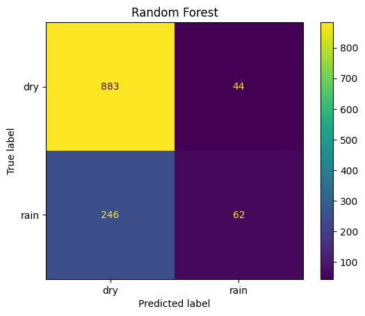

```python
_ = model_evaluator(RandomForestClassifier(n_estimators=100), "Random Forest")
```

Secondly, the Gradient Boosting.

```
EVALUATION METRICS FOR 'Gradient Boosting'
===============================
| Accuracy          | 74.818% |
===============================
| Balanced Accuracy | 54.608% |
===============================
| Precision (PPV)   | 48.352% |
===============================
| Sensitivity (TPR) | 14.286% |
===============================
| Specificity (TNR) | 94.930% |
===============================
```

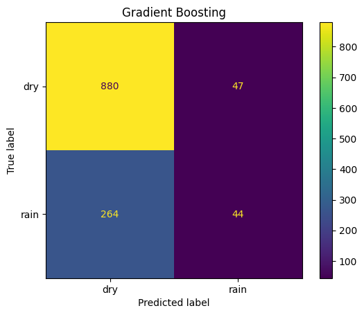

```python
_ = model_evaluator(GradientBoostingClassifier(n_estimators=100), "Gradient Boosting")
```